# Module 9: Practice Problems Solutions - Descriptive Statistics

Course: ISM2411 Python for Business

Instructor: Dr. Smith • Version: 0.12.0 • University of South Florida

This document provides detailed solutions to the practice problem set on hypothesis testing and confidence intervals. Each question includes the Python code as well as an in-depth discussion of the results and underlying statistical concepts.

# Question 1: Descriptive Statistics with pandas

**Task:**  
Given the following sales dataset:

```python
sales = [180, 215, 200, 230, 210, 195, 225, 240, 235, 205, 220, 210, 200, 225, 230]
```

Compute the mean, median, mode, variance, and standard deviation using pandas.

## Solution

```python
import pandas as pd

# Sales dataset
sales = [180, 215, 200, 230, 210, 195, 225, 240, 235, 205, 220, 210, 200, 225, 230]
df = pd.DataFrame(sales, columns=['sales'])

# Calculating descriptive statistics
mean_sales = df['sales'].mean()
median_sales = df['sales'].median()
mode_sales = df['sales'].mode()[0]  # mode() returns a Series; we take the first value
variance_sales = df['sales'].var()
std_sales = df['sales'].std()

print("Mean:", mean_sales)
print("Median:", median_sales)
print("Mode:", mode_sales)
print("Variance:", variance_sales)
print("Standard Deviation:", std_sales)
```

```
Mean: 214.66666666666666
Median: 215.0
Mode: 200
Variance: 280.23809523809524
Standard Deviation: 16.740313474905278
```

## Discussion

- **Mean:** Represents the average value of the sales. It gives a measure of central tendency.
- **Median:** The middle value when the data is sorted. It is less affected by outliers than the mean.
- **Mode:** The most frequently occurring sales value in the dataset.
- **Variance:** Measures the dispersion of the sales values around the mean. A higher variance indicates that the data points are spread out more.
- **Standard Deviation:** The square root of the variance, providing the average distance of each data point from the mean in the same units as the original data.

# Question 2: Data Visualization and Distribution Analysis

**Task:**  
Using the sales dataset from Question 1, generate: - A histogram with a kernel density estimate (KDE) - A box plot

## Solution

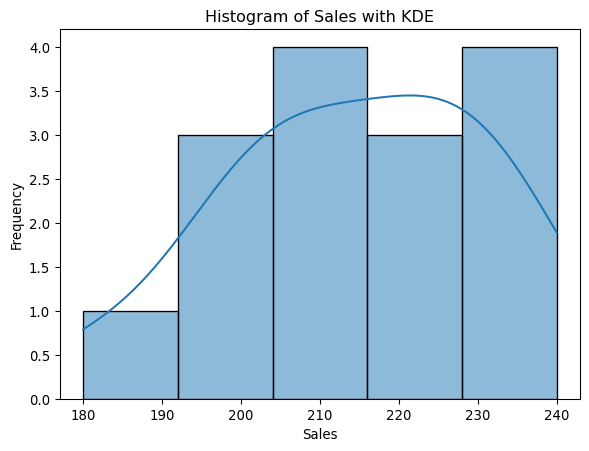

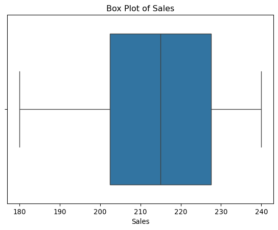

```python
import seaborn as sns
import matplotlib.pyplot as plt

# Histogram with KDE
plt.figure()
sns.histplot(df['sales'], bins=5, kde=True)
plt.title("Histogram of Sales with KDE")
plt.xlabel("Sales")
plt.ylabel("Frequency")
plt.show()

# Box plot
plt.figure()
sns.boxplot(x=df['sales'])
plt.title("Box Plot of Sales")
plt.xlabel("Sales")
plt.show()
```

## Discussion

- **Histogram with KDE:**  
  This plot displays the distribution of sales data. The histogram shows how frequently sales values occur, while the overlaid KDE provides a smooth estimation of the distribution shape. It helps identify skewness (asymmetry) in the data.
- **Box Plot:**  
  The box plot illustrates the data’s quartiles, with the box showing the interquartile range (IQR) and the line inside representing the median. It also flags potential outliers with points beyond the whiskers. Together, these plots provide a visual summary of the distribution, central tendency, spread, and potential anomalies in the data.

# Question 3: Understanding the Normal Distribution

**Task:**  
Explain the role of the normal distribution in hypothesis testing by defining and discussing: - Mean (µ) - Standard Deviation (σ) - Z-Score - Critical cutoff points (e.g., -1.96 and +1.96 for a 95% confidence level)

## Discussion

- **Mean (µ):**  
  The mean is the central value of a distribution. For a normal distribution, it is the peak where the data points cluster.
- **Standard Deviation (σ):**  
  This measures the spread of the distribution around the mean. A smaller σ indicates that the data points are tightly clustered, while a larger σ indicates a wider spread.
- **Z-Score:**  
  The z-score represents how many standard deviations an element is from the mean. It standardizes values, allowing comparison across different normal distributions.
- **Critical Cutoff Points:**  
  In a two-tailed test at a 95% confidence level, the critical z-values are approximately -1.96 and +1.96. Values beyond these thresholds lead to rejection of the null hypothesis. These cutoff points help determine the probability of observing a test statistic as extreme as, or more extreme than, the one calculated from the sample data.

The normal distribution is foundational in inferential statistics because many hypothesis tests assume that the data are normally distributed, especially when sample sizes are large.

# Question 4: One-Sample T‑Test: Customer Satisfaction

**Task:**  
Given the sample ratings below and a target rating of 4.0, perform a one-sample t‑test:

```python
ratings = [4.1, 4.3, 3.9, 4.4, 4.0, 4.2, 4.1]
```

## Solution

```python
import numpy as np
from scipy import stats

# Customer satisfaction ratings
ratings = np.array([4.1, 4.3, 3.9, 4.4, 4.0, 4.2, 4.1])
benchmark = 4.0

# Perform one-sample t-test
t_stat, p_value = stats.ttest_1samp(ratings, benchmark)
print("T-Statistic:", t_stat)
print("P-Value:", p_value)
```

```
T-Statistic: 2.1997067253203038
P-Value: 0.07013051445189913
```

## Discussion

- **Interpretation of T-Statistic:**  
  The t-statistic indicates the degree to which the sample mean deviates from the benchmark (4.0) relative to the sample variability.
- **Interpretation of P-Value:**  
  A p-value below 0.05 would suggest that there is a statistically significant difference between the sample mean and the benchmark. In this case, if p < 0.05, we reject the null hypothesis and conclude that the average customer satisfaction rating is significantly different from 4.0.

# Question 5: One-Sample T‑Test: Production Cost Analysis

**Task:**  
A company benchmarks its production cost per unit against an industry standard of $50 using the following data:

```python
production_costs = [52, 47, 50, 54, 48, 49, 51]
```

## Solution

```python
# Production costs per unit
production_costs = np.array([52, 47, 50, 54, 48, 49, 51])
industry_standard = 50

# Perform one-sample t-test
t_stat, p_value = stats.ttest_1samp(production_costs, industry_standard)
print("T-Statistic:", t_stat)
print("P-Value:", p_value)
```

```
T-Statistic: 0.15681251204679833
P-Value: 0.8805362023620829
```

## Discussion

- **Interpretation:**  
  If the p-value is less than 0.05, it indicates that the average production cost is statistically significantly different from $50. This result may prompt further investigation into the production process or cost drivers if the deviation is practically significant for business decisions.

# Question 6: Two-Sample T‑Test: Marketing Campaign Performance

**Task:**  
Compare the effectiveness of two marketing campaigns using the following sales data: - **Campaign A:** `[110, 108, 115, 112, 109, 113, 111]` - **Campaign B:** `[105, 107, 106, 102, 108, 104, 103]`

## Solution

```python
# Sales data for two marketing campaigns
campaign_A = np.array([110, 108, 115, 112, 109, 113, 111])
campaign_B = np.array([105, 107, 106, 102, 108, 104, 103])

# Perform a two-sample t-test
t_stat, p_value = stats.ttest_ind(campaign_A, campaign_B)
print("T-Statistic:", t_stat)
print("P-Value:", p_value)
```

```
T-Statistic: 5.0213181898418195
P-Value: 0.0002984740155265536
```

## Discussion

- **Interpretation:**  
  A statistically significant p-value (p < 0.05) would suggest that there is a significant difference in the average sales generated by Campaign A compared to Campaign B. This information is critical for assessing which campaign performs better and could inform future marketing strategies.

# Question 7: Two-Sample T‑Test: Branch Revenue Comparison

**Task:**  
Two branches report the following monthly revenues (in thousands): - **Branch X:** `[160, 165, 158, 170, 168, 163, 167]` - **Branch Y:** `[155, 157, 159, 150, 160, 158, 156]`

## Solution

```python
# Monthly revenue data for two branches
branch_X = np.array([160, 165, 158, 170, 168, 163, 167])
branch_Y = np.array([155, 157, 159, 150, 160, 158, 156])

# Perform a two-sample t-test
t_stat, p_value = stats.ttest_ind(branch_X, branch_Y)
print("T-Statistic:", t_stat)
print("P-Value:", p_value)
```

```
T-Statistic: 3.8705156917063674
P-Value: 0.002225800374462607
```

## Discussion

- **Interpretation:**  
  Here, the t-statistic quantifies the difference in means between the two branches relative to the variability of the data. A p-value below 0.05 would indicate a statistically significant difference in average revenue, suggesting that one branch may be outperforming the other. Such insights can help in making decisions related to resource allocation or targeted improvements.

# Question 8: Paired T‑Test: Evaluating a New Pricing Strategy

**Task:**  
Assess the impact of a new pricing strategy using paired sales data before and after implementation: - **Sales Before:** `[120, 125, 123, 130, 128, 122, 127]` - **Sales After:** `[125, 130, 127, 135, 133, 126, 130]`

## Solution

```python
# Paired sales data before and after the new pricing strategy
sales_before = np.array([120, 125, 123, 130, 128, 122, 127])
sales_after = np.array([125, 130, 127, 135, 133, 126, 130])

# Perform a paired t-test
t_stat, p_value = stats.ttest_rel(sales_before, sales_after)
print("T-Statistic:", t_stat)
print("P-Value:", p_value)
```

```
T-Statistic: -14.891918303873103
P-Value: 5.76973798428209e-06
```

## Discussion

- **Interpretation:**  
  The paired t-test compares the means of the two related samples (sales before and after the pricing strategy). A significant p-value (p < 0.05) implies that the change in sales is statistically significant, indicating that the new pricing strategy has likely had an impact on sales performance. This supports making informed business decisions based on the observed improvement.

# Question 9: Correlation Analysis and Business Insights

**Task:**  
Simulate a dataset with the following variables: - **sales:** Normally distributed with mean 250 and standard deviation 30. - **marketing_spend:** Normally distributed with mean 80 and standard deviation 15. - **customer_satisfaction:** Uniformly distributed between 1 and 5.

Compute the Pearson correlation matrix and visualize it using a heatmap.

## Solution

```
                          sales  marketing_spend  customer_satisfaction
sales                  1.000000        -0.136422              -0.030357
marketing_spend       -0.136422         1.000000               0.108685
customer_satisfaction -0.030357         0.108685               1.000000
```

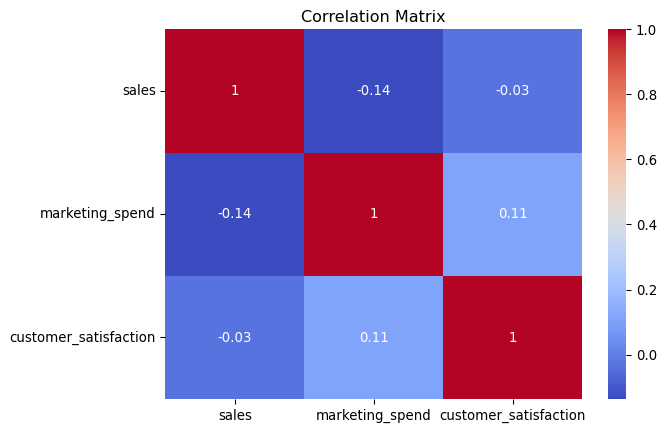

```python
import numpy as np
import pandas as pd
import seaborn as sns
import matplotlib.pyplot as plt

# Set seed for reproducibility
np.random.seed(42)

# Simulate data for 100 observations
sales_data = np.random.normal(250, 30, 100)
marketing_spend = np.random.normal(80, 15, 100)
customer_satisfaction = np.random.uniform(1, 5, 100)

# Create a DataFrame
df_corr = pd.DataFrame({
    'sales': sales_data,
    'marketing_spend': marketing_spend,
    'customer_satisfaction': customer_satisfaction
})

# Compute Pearson correlation matrix
correlation_matrix = df_corr.corr()
print(correlation_matrix)

# Visualize the correlation matrix using a heatmap
plt.figure()
sns.heatmap(correlation_matrix, annot=True, cmap='coolwarm')
plt.title("Correlation Matrix")
plt.show()
```

## Discussion

- **Correlation Matrix:**  
  This matrix shows the Pearson correlation coefficients between pairs of variables.
  - A **positive correlation** (values close to +1) indicates that as one variable increases, the other tends to increase as well.
  - A **negative correlation** (values close to -1) suggests that as one variable increases, the other tends to decrease.
  - A **near-zero correlation** indicates little to no linear relationship between the variables.
- **Business Implications:**  
  Understanding these relationships can help identify factors that might influence sales or customer satisfaction. For example, a strong positive correlation between marketing spend and sales could justify increased investment in marketing efforts.

# Question 10: Confidence Interval Estimation: Production Yield

**Task:**  
Given the following production yield data, compute a 95% confidence interval for the mean production yield:

```python
yields = [95, 98, 97, 100, 96, 99, 101, 94, 97, 98]
```

## Solution

```python
# Production yield data
yields = np.array([95, 98, 97, 100, 96, 99, 101, 94, 97, 98])
n = len(yields)

# Calculate sample mean and standard deviation
mean_yields = np.mean(yields)
std_yields = np.std(yields, ddof=1)  # Using ddof=1 for sample standard deviation
se_yields = std_yields / np.sqrt(n)   # Standard error

# Degrees of freedom
df_degrees = n - 1

# Critical t-value for 95% confidence
t_crit = stats.t.ppf(0.975, df_degrees)

# Confidence interval calculation
ci_lower = mean_yields - t_crit * se_yields
ci_upper = mean_yields + t_crit * se_yields

print("Mean Production Yield:", mean_yields)
print("95% Confidence Interval: [{:.2f}, {:.2f}]".format(ci_lower, ci_upper))
```

```
Mean Production Yield: 97.5
95% Confidence Interval: [95.95, 99.05]
```

## Discussion

- **Interpretation of the Confidence Interval:**  
  The 95% confidence interval provides a range within which we are 95% confident that the true mean production yield lies. If this interval is narrow, it suggests that our estimate is precise; if it is wide, there is more uncertainty.
- **Business Context:**  
  Knowing the confidence interval helps in quality control and process optimization. For instance, if the interval does not meet a specified production standard, it may indicate the need for process improvements or further investigation.

Happy coding, and may these solutions enhance your understanding of hypothesis testing and confidence interval estimation in a business analytics context!

ISM4641 Python for Business - Version 0.12.0